# Microclimate structures communities, predation and herbivory in the High Arctic - Kankaanpää - - Journal of Animal Ecology - Wiley Online Library

[Journal of Animal Ecology](https://besjournals.onlinelibrary.wiley.com/journal/13652656)

[Early View](https://besjournals.onlinelibrary.wiley.com/toc/13652656/0/0)

[figure not shown]

RESEARCH ARTICLE

Open Access

# Microclimate structures communities, predation and herbivory in the High Arctic

[Tuomas Kankaanpää](https://besjournals.onlinelibrary.wiley.com/action/doSearch?ContribAuthorStored=Kankaanp%C3%A4%C3%A4%2C+Tuomas)

[Nerea Abrego](https://besjournals.onlinelibrary.wiley.com/action/doSearch?ContribAuthorStored=Abrego%2C+Nerea)

[Eero Vesterinen](https://besjournals.onlinelibrary.wiley.com/action/doSearch?ContribAuthorStored=Vesterinen%2C+Eero)

[Tomas Roslin](https://besjournals.onlinelibrary.wiley.com/action/doSearch?ContribAuthorStored=Roslin%2C+Tomas)

First published: 24 December 2020

https://doi.org/10.1111/1365-2656.13415

## Abstract

1. In a warming world, changes in climate may result in species‐level responses as well as changes in community structure through knock‐on effects on ecological interactions such as predation and herbivory. Yet, the links between these responses at different levels are still inadequately understood. Assessing how microclimatic conditions affect each of them at local scales provides information essential for understanding the consequences of macroclimatic changes projected in the future.
2. Focusing on the rapidly changing High Arctic, we examine how a community based on a common resource species (avens, *Dryas* spp.), a specialist insect herbivore (*Sympistis zetterstedtii*) and natural enemies of lepidopteran herbivores (parasitoids) varies along a multidimensional microclimatic gradient. We ask (a) how parasitoid community composition varies with local abiotic conditions, (b) how the community‐level response of parasitoids is linked to species‐specific traits (koino‐ or idiobiont life cycle strategy and phenology) and (c) whether the effects of varying abiotic conditions extend to interaction outcomes (parasitism rates on the focal herbivore and realized herbivory rates).
3. We recorded the local communities of parasitoids, herbivory rates on *Dryas* flowers and parasitism rates in *Sympistis* larvae at 20 sites along a mountain slope. For linking community‐level responses to microclimatic conditions with parasitoid traits, we used joint species distribution modelling. We then assessed whether the same abiotic variables also affect parasitism and herbivory rates, by applying generalized linear and additive mixed models.
4. We find that parasitism strategy and phenology explain local variation in parasitoid community structure. Parasitoids with a koinobiont strategy preferred high‐elevation sites with higher summer temperatures or sites with earlier snowmelt and lower humidity. Species of earlier phenology occurred with higher incidence at sites with cooler summer temperatures or later snowmelt. Microclimatic effects also extend to parasitism and herbivory, with an increase in the parasitism rates of the main herbivore *S. zetterstedtii* with higher temperature and lower humidity, and a matching increase in herbivory rates.
5. Our results show that microclimatic variation is a strong driver of local community structure, species interactions and interaction outcomes in Arctic ecosystems. In view of ongoing climate change, these results predict that macroclimatic changes will profoundly affect arctic communities.

## 1 INTRODUCTION

With global climate change and habitat modification, communities are changing across the world. These changes have resulted in changes in species ranges (Chen et al., 2011; Hickling et al., 2006; Hill et al., 2002; Parmesan et al., 1999), and ultimately in community structure (Habel et al., 2016). While abiotic impacts on species distributions are well established, little is known about the simultaneous effects of microclimate on the local composition of communities, on species interactions, and on the outcome of these interactions in terms of realized rates of e.g. herbivory and predation (Eggers et al., 2003; Parejo, 2016; Tylianakis et al., 2008, 2010). Where warming experiments have suggested several mechanisms through which climate change affects parasitism (Thierry et al., 2019) and herbivory (Liu et al., 2011), corresponding changes in nature have been hard to establish. Large‐scale surveys suggest a direct link between macroclimate and predation rates (Romero et al., 2018), while the relationship between macroclimate and herbivory appears less clear than previously thought (Moles et al., 2011)—leaving net effects remain to be established.

During the last decade, much theory has been developed on how climate change affects species interactions, in particular predator–prey interactions (Dell et al., 2014; Pepi et al., 2018; Uszko et al., 2017). Recent work suggests that the net outcome of predator–prey interactions is driven by the asymmetries in species responses to temperature, as compounded by different foraging strategies (Dell et al., 2014; Pepi et al., 2018). For species interacting during a limited time window, shifts in phenology of the two interaction partners may result in phenological asynchrony and weakened interactions, with idiosyncratic patterns among different types of interactions (e.g. Kharouba et al., 2018). While host–parasitoid interactions comprise one of the globally most abundant types of predator–prey interactions (Godfray, 1994; Hawkins, 2005), little is known about how changing environmental conditions may affect their interaction outcomes.

To gain a more predictive understanding how communities change across environmental and spatiotemporal gradients, we need to understand not only how communities change in terms of species composition, but also in terms of biotic interactions. Examining how the strengths of both trophic interactions and interaction outcomes (such as herbivory and predation rates) change along environmental gradients may provide more mechanistic insights into community dynamics than examining species composition alone. For instance, changes in observed in herbivore communities when moving towards higher elevation or latitude are, more often than not, associated with a decrease in herbivory (Andrew et al., 2012; Kambach et al., 2016; Rasmann et al., 2014). By comparison, changes in parasitoid communities along elevation gradients appear to have more varied effects on parasitism rates (Thierry et al., 2019)—despite a general drop in parasitoid diversity towards higher elevations (Corcos et al., 2018; Maunsell et al., 2015; Morris et al., 2015). Identifying the traits that determine species‐level responses (i.e. the so called response traits) further allows us to understand the mechanisms underlying community dynamics (McGill et al., 2006). For instance, concerning insect communities, insects from higher elevations are typically darker and characterized by larger wings (relative to body weight) than their counterparts at lower elevations, which are traits allow them to fly in colder conditions (Downes, 1965; Hodkinson, 2005).

One way of approaching community change through time is to assess current patterns in space, along environmental gradients. If we can find consistencies in how communities are organized along such contemporary gradients, then we may expect the same organizing principles to structure communities through time. In particular, altitudinal gradients can be used as ‘space‐for‐time’ substitutes of projected environmental changes (Körner, 2007). Along elevation, abiotic conditions vary locally as they might be expected to change globally in the future. Ecological communities found at higher elevations are generally better adapted to the colder and harsher conditions than at lower elevations, and vice versa (Sundqvist et al., 2013).

The High Arctic offers a unique observatory for studying the impact of rapid climate change. Here, climate warming is faster than anywhere else (IPCC AR5;WG1, 2013), whereas community structure and species interaction networks are relatively simple due to the characteristic low species richness (Elton, 1927; Hodkinson & Coulson, 2004; Legagneux et al., 2012; Post et al., 2009; Schmidt et al., 2017; Wirta et al., 2015). At the same time, other anthropogenic effects are relatively limited across some largely uninhabited areas of the Arctic, allowing us to quantify the specific effects of climate.

In a parallel study (Kankaanpää, Vesterinen, et al., 2020), we showed how the imprint of recent climate change can be discerned in arctic parasitoid communities. We proposed that these changes have likely repercussions for both herbivory and pollination (Kankaanpää, Vesterinen, et al., 2020). In this study, we examine the relation between contemporary abiotic conditions and local variation within a multi‐trophic level community at a single high‐arctic site in Northeast Greenland. Complementary to the patterns previously reported at a large scale, we now ask (a) how parasitoid community structure varies with local abiotic conditions; (b) whether parasitoid responses to abiotic conditions are deducible from their traits (specifically life cycle strategy and species‐specific phenology); and (c) whether the abiotic predictors explaining variation in parasitoid community composition also determine parasitism and herbivory rates. Our main hypothesis is that local environmental conditions affect parasitoid communities and consequently also the outcome of interactions (herbivory and parasitism). Specifically, we expect traits describing parasitoid phenology and parasitism strategy to influence the response of parasitoids to varying environmental conditions.

## 2 MATERIALS AND METHODS

### 2.1 Study system

The sampling was carried out in Zackenberg, a High Arctic site located on the Northeast coast of Greenland (74°28−N, 20°34−W, Figure 1). This region is characterized by a High Arctic climate, where the mean monthly average temperatures range from −19,4°C in February to plus 6.1°C in July. The annual precipitation is on average 200 mm, which is mostly received as snow (INTERACT, 2015). Within the study area, the vegetation of dry areas is dominated by graminoid and shrub tundra, with nearly barren fell fields as another common habitat (Bay, 1998). In deep recesses, we find permanent snow patches. Much of the mineral soil is of Cretaceous seabed origin (Kroon et al., 2010), favouring calciphilic plants.

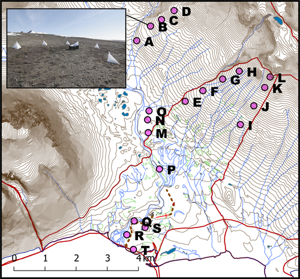

**FIGURE 1**

Open in figure viewer[PowerPoint](https://besjournals.onlinelibrary.wiley.com/action/downloadFigures?id=jane13415-fig-0001&doi=10.1111%2F1365-2656.13415)

Distribution of study sites (A through T) in the Zackenberg valley, including a photograph from site B showing the layout of emergence traps around a central malaise trap. The malaise trap measures 1.2 m in length. The map shows streams and 10‐m contour lines

Within this high‐arctic system, we focus on the functionally dominant guilds of the arctic tundra: plants, invertebrate herbivores and their enemies. Specifically, the focal community is based on the widespread and locally abundant flowering plant *Dryas* as the defining primary producer. Within the study area, most individuals are hybrids *Dryas octopetala* × *integrifolia* (Høye et al., 2007). Associated with this plant are multiple species of Lepidoptera, all with herbivorous larvae. Massively dominant among these is the noctuid moth *Sympistis zetterstedtii* (Staudinger, 1857) (Várkonyi & Roslin, 2013). Young larvae of this species feed specifically on the stamens and pistils of *Dryas* flowers (florivory). The Lepidopteran larvae are preyed upon by a host of parasitoid wasps and flies, some of which are themselves attacked by hyperparasitoids (Várkonyi & Roslin, 2013; Wirta et al., 2015). Altogether there are roughly 36 species of parasitoids linked to lepidopteran herbivores (Várkonyi & Roslin, 2013; Wirta et al., 2015). Younger larvae of *Sympistis* and other species of lepidoptera are attacked by many koinobiont wasp taxa in families Ichneumonidae and Braconidae, with *Microplitis lugubris* (Ruthe, 1860; Hymenoptera: Braconidae) being one of the most abundant parasitoids of *Sympistis*. Just prior to pupation and during the pupal phase, *Sympistis* larvae are also attacked by idiobiont parasitoids in the same wasp families. Adding to the local parasitoid communities are four species of parasitoid flies (Diptera: Tachinidae), all of which use various lepidopteran hosts.

With this specific study system in mind, we focus on two types of response traits (life cycle strategy and species‐specific phenology) and two interaction outcomes affecting ecosystem functioning (parasitism and herbivory rates).

The first response that we consider is species’ phenology, here specifically based on the mean occurrence dates of adult parasitoids. Changes in phenology are arguably the best recorded effect of climate change on organisms (Parmesan, 2006; Visser & Both, 2005; Walther, 2010). Phenological responses are not equal among species (Ovaskainen et al., 2013) and diverging changes in the seasonal activities of interacting species are likely to affect the level of synchrony between their life cycles (Both et al., 2009; Jeffs & Lewis, 2013; Memmott et al., 2007). This, in turn, is expected to have demographic consequences on the interacting species (Miller‐Rushing et al., 2010). As a general pattern, species active early in the season are typically the most sensitive climatic factors (Forrest, 2016). In our specific study system, we expect the timing of snowmelt to have more pronounced demographic effects on species with an early phenology.

The second response trait that we consider is parasitoid life cycle strategy. Parasitoids can be classified into idiobionts and koinobionts, with the former halting host development and the latter allowing its host to grow and develop before consuming it (Godfray, 1994; Godfray & Shimada, 1999; Quicke, 2015). As these strategies affect all aspects of parasitoid–host interactions, they are associated with a suite of other ecological traits, such as the time window of host accessibility, adult longevity and fecundity (Mayhew & Blackburn, 1999). In the Arctic, parasitism strategy is likely to affect the exposure of overwintering parasitoids to environmental conditions (Hance et al., 2007; Kankaanpää, Vesterinen, et al., 2020). Overall, we expect to find differences in the conditions favoured by idiobiont versus koinobiont parasitoids, with koinobionts being relatively more common in more harsh conditions with less snow cover and at higher elevations (Kankaanpää, Vesterinen, et al., 2020).

To quantify local predation and herbivory rates, we focus on two metrics: First, we measure parasitism rates in a key herbivore. Compared to e.g. parasitoid abundance, such rates better approximate the mortality imposed on the host species, as they incorporate the separate effects of parasitoid abundance, efficacy and fecundity, as well as host population density. Second, we focus on a specific type of herbivory, i.e. florivory. This is because florivory directly affects the reproductive organs of the plants, affecting their reproductive fitness.

### 2.2 Sampling design

To include environmental variation akin to that associated with Arctic climate change, we selected 20 sites at different elevations along the South‐West facing slope of the Aucella mountain in Northeast Greenland (Figure 1). Sites were arranged into three elevational gradients with at least 100 vertical metres in between the adjacent sites and into two lowland configurations: one to the South and one to the North of the research station. All sites were located in as similar *Dryas*‐dominated habitats as possible. The sites varied in the local timing of snowmelt and in their temperatures, as due both to their elevation and to independent variation in the local topography. Importantly, due to the shading effects of the adjacent Zackenberg mountain and the fog that commonly covers the valley bottom, the summer temperatures on our elevation gradient were inverted with highest mean temperatures recorded at the highest elevations. Furthermore, the sites exhibited orthogonal variation in humidity, reflecting the combined impact of the amount of snow in the areas surrounding the site, inclination and the water retention properties of the soil. Overall, we thus measured the following abiotic environmental variables at each site: (a) the elevation of the sampling sites, (b) the date of snow melt in the sampling sites, (c) temperature and (d) relative humidity at a height of 10 cm at every sampling site. For the latter two metrics, we used EL‐USB‐2 (Lascar electronics) loggers mounted under a white plastic shade.

Sampling at each site was initiated once the snow had cleared. To characterize the local community of adult parasitoids, we placed ten sticky and five emergence traps at each site. The traps were monitored weekly (every 6 days) in an identical manner during two consecutive summers of 2015 and 2016, totalling a maximum of 18 visits per site (7.6.–3.8.2015 and 7.6.–1.8.2016).

To relate the observed phenology of adult parasitoids (above) to the phenology of their main host, *S. zetterstedtii*, we used *Dryas* flowering as a proxy. Thus, throughout the summer, we monitored the progress and density of flowering at five 1‐square metre monitoring plots per site. At every visit, we recorded the number of small buds, buds with visible petals, open flowers and senescent flowers, as well as the number of flowers damaged by larvae of *S. zetterstedtii*.

To record parasitism rates, we searched for and collected local larvae of *S. zetterstedtii* on *Dryas*. Not to affect the counts of herbivory within the plots, we did this in the surrounding areas rather than within the plots themselves. Since *Sympistis* larvae are nocturnal, the majority of larvae were collected during night‐time (23–06 hr). At each site, larval searches were targeted on the particular phenological phase when *Dryas* flowering had just started and both buds and flowers were available. At this point, *Sympistis* larvae were typically at their third instar. We attempted to collect at least 50 larvae from each site during both years, but at a few sites the larvae were scarce to the point of few being found (for a graphical representation of local sample sizes, see Figure S1). Additional larvae (*n* = 139, 7% of the overall material) were caught with passive sticky traps.

### 2.3 Sample processing and bioinformatics analyses

Adult parasitoids were removed from sticky traps on the same day as collected from the field using an orange oil product (Romax, Barrettine environmental), and subsequently stored in 96% ethanol at −20°C. As a measure of larval phenology, the hand‐collected lepidopteran larvae were weighted before storage in ethanol. We then used DNA barcoding of 418 and 117 bp sequences of the CO1 region to identify both adult and larval parasitoids respectively. These sequences were deemed to satisfactorily separate the modest number of target species, for which a comprehensive CO1 barcode library was already compiled for the study area. (Wirta et al., 2016) For a full account of the extraction format, primers, PCR setup and sequencing conditions used for molecular identification of adult parasitoids, go to the online Supporting Information, text S1.2 and S1.3. The trimming, quality control and taxonomic assignment of the raw sequences were carried out as outlined in Vesterinen et al. (2018), with the bioinformatics analysis explained in online Supporting Information, text S1.4. Finally, the molecular identifications were checked against trap level voucher photographs.

### 2.4 Measurement of biological traits

To characterize parasitoids by their traits, we assigned three traits to each species. First, we classified them by parasitism strategy as being either idiobionts or koinobionts, a dichotomy correlated with many other traits from size to diet breadth (Mayhew & Blackburn, 1999; Quicke, 2015; Sheehan & Hawkins, 1991). For this classification, we followed previous work at the study site by (Várkonyi & Roslin, 2013) and the encyclopaedia of the Greenlandic arthropod fauna provided by (Böcher et al., 2015). Second, we classified the parasitoids as being either primary or secondary parasitoids (with the latter also called hyperparasitoids). Third, we classified the parasitoids into species of early, middle and late phenology, while controlling for variation stemming from differences in spatial and interannual occurrence patterns. This was done by modelling the occurrence dates of individuals as a linear function of species, sampling site and year, and then predicting the species‐specific occurrence dates for a constant year and sampling site. These dates were then used to split the species into three classes, cutting at points of discontinuities in the data. For exact details, see online Supporting Information, Figure S2. The resulting phenological classes are in line with phenologies described in Várkonyi and Roslin (2013; for species‐specific assignments, see Figure 3; online Supporting Information, Figure S2).

### 2.5 Statistical analyses

To resolve how parasitoid community structure varies with local abiotic conditions; whether parasitoid responses to abiotic conditions are deducible from their traits (specifically life cycle strategy and species‐specific phenology); and whether the abiotic predictors explaining variation in parasitoid community composition also determine parasitism and herbivory rates, we took a two‐pronged approach. To model community‐level responses, we first used a multivariate approach—i.e. a joint species distribution model of the occurrence of the 32 species as a function of the species‐specific traits, abiotic conditions and spatiotemporal structure of the data (i.e. different traps sampled within different sampling sites at different times). To then model individual interaction outcomes, we used univariate models of three individual responses: (a) the adult parasitoid abundance of the two most common koinobiont parasitoid species (*M. lugubris* and *H. frigidus*), (b) the parasitism rates inflicted by the same species on their host *S. zetterstedtii*, and (c) the florivory rates inflicted by the herbivore *S. zetterstedtii* on its host plant *Dryas*. In each case, we modelled the responses with the same environmental covariates, thereby allowing us to dissect the relative impacts of the same environmental factors at each level of organisation. Below, we will provide the details for each approach.

#### 2.5.1 How is parasitoid community‐level variation linked to species' traits?

To model the parasitoid community consisting of 32 species, we applied Hierarchical Modelling of Species Communities (HMSC; Ovaskainen & Abrego, 2020b; Ovaskainen et al., 2017) using Hmsc‐R software (Tikhonov et al., 2019). HMSC is a joint species distribution modelling framework (Warton et al., 2015) that enables the integration of data on species occurrences, environmental covariates, species traits and phylogenetic relationships in a single encompassing model (Ovaskainen & Abrego, 2020b; Ovaskainen et al., 2017). In HMSC, the response variable is the vector consisting of the occurrences of all species in each sampling unit. HMSC includes species‐specific regressions that estimate the responses of the species to environmental covariates. These responses are used as a response variable in a second‐level regression, which models how the species responses to environmental covariates depend on species traits.

The joint species model was built as follows. As response data, we used a presence–absence matrix of the parasitoid species detected in each sampling unit (trap sampling event). We used occurrence rather than abundance, because the data showed only limited variation in species‐specific abundances among occupied traps. As a consequence, the main information was in whether the species were present or absent in a trap (Figure S3). As fixed explanatory variables, we included (a) the site‐specific component of mean temperature (see below) as a continuous variable (b) the snow melt day in the sampling sites as a continuous variable, (c) the site‐level mean air humidity as a continuous variable, (d) the trap type as a categorical variable with two levels (sticky trap or emergence trap), (e) year as categorical variable with two levels (2015 or 2016), and (f) the week‐specific component of temperature (see below) in each sampling site as a continuous variable. The spatiotemporal structure of the data was accounted for by including one random effect representing the study site and another random effect representing the sampling weeks. In the latter, the sampling weeks of different years were treated as unique levels. As species‐specific traits, we included the parasitoid strategy of the species as a categorical variable with two levels (koino‐ or idiobiont life cycle strategy) and the phenology of the species as a categorical variable with three levels (early, medium and late). Additionally, to explore whether the responses of species with different traits were constrained by their phylogeny, we included a taxonomic tree which included eight levels ranging from species to class. For analyses, this tree was then converted to a taxonomic distance matrix.

To decompose the raw temperature data measured during the study period into its spatial and temporal components, we partitioned the raw temperatures recorded for 6‐day trapping periods (ranging between 7.6.–30.7.2015 and 7.6.–25.7.2016 for the earliest sites and 12.7.‐2.8.2015 and 28.6.‐28.7.2016 for the latest site) into variation at the site and week levels by the following approach. We first modelled temperatures as a function of site, week and year and the interactions of site and week with year using linear regression. Site temperature was then predicted for each site from this model with year and week at mean values. Weekly temperatures were correspondingly predicted for each week while giving the site a constant value. The residuals of the model fit were added back to the weekly temperatures as these contain the transect‐specific differences in the only partially overlapping trapping periods.

Site‐specific humidity was produced from the measurements of relative humidity by subsequently removing the effects of temperature, snowmelt and elevation, reaching an independent covariate which reflects the soil water content (for a validation of this metric, see Figure S4).

We fitted the model with the Hmsc‐R software (Tikhonov et al., 2019) assuming the default priors and Markov chain Monte Carlo (MCMC) setting, which, as explained in Ovaskainen and Abrego (2020a), have been chosen to be generally applicable. For each of two MCMC chains, we sampled the posterior distribution for 45,000 iterations, of which the first 15,000 iterations were discarded and the remaining were thinned by 100 to yield 300 posterior samples per chain and thus 600 posterior samples in total. We assessed satisfactory convergence of the MCMC chains through the potential scale reduction factors of the estimated parameters.

To quantify how much the explanatory variables as well as random effects part of the model explained the variation in the parasitoid community, we applied the variance partitioning approach of Ovaskainen et al. (2017). Likewise, we quantified how much the responses of the species were explained by their parasitic strategy and phenology. The overall explanatory power of the model was assessed by computing the area under the curve (AUC) value, which measures the model performace in terms of discrimination (Norberg et al., 2019).

Finally, we used the fitted model to predict how species with different traits respond to abiotic gradients along the elevational gradient. For these predictions, we used the ranges of the environmental data (i.e. interpolation). We specifically predicted: (a) the proportions of koino‐ and idiobiont species along the temperature, snow melt day and humidity gradients, and (b) the proportions of early and late phenology species along the temperature, snow melt day and humidity gradients.

#### 2.5.2 Parasitism rates in *S. zetterstedtii* and spatial variation in herbivory rates

To examine abiotic impacts on the parasitism of herbivores, we focused on two different responses: adult parasitoid abundance and parasitism rates. Together, the two metrics of parasitoid abundance (as scored from adult parasitoids vs. parasitized larvae respectively) are likely to provide complementary insights. By comparing the two, we can infer how parasitoid abundance is translated into herbivore mortality in a specialist versus a generalist parasitoid, and whether the factors that affect the spatial distribution of adult parasitoids are also reflected in parasitoid efficiency (as larval parasitism rates are logically a product of parasitoid numbers and parasitism success).

First, we analysed the adult parasitoid abundance of the two most common koinobiont parasitoid species found within larvae of *S. zetterstedtii*: *M. lugubris* (Hymenoptera: Braconidae) and *Hyposoter frigidus* (Lundbeck, 1897; Hymenoptera: Ichneumonidae), accounting for 1615 and 124 individuals (29% and 2% of all parasitoid individuals encountered) respectively. For these two species, adult abundances varied substantially, allowing for informative analysis. Thus, for both species, we modelled the pooled counts of adults caught at the site using generalized linear models. We started model selection from the same model structure as in the HMSC model, but assuming a quasipoisson error distribution and a log link function for the response variable. As there is reason to expect koinobiont parasitoid abundances to be affected by phenological mismatches (see Section 1), we included the time difference between *Dryas* flowering and the mean flight date of the respective parasitoid species as an explanatory variable. For the abundance of *M. lugubris,* the plotting of residuals against fitted values indicated a nonlinear pattern in the data. We therefore refitted the model as a generalized additive model (GAM) with a smoothing spline for the day of snowmelt. The number of knots (4 for snowmelt smoother in the parasitoid abundance models), was selected to be the largest possible while maintaining a simple, unimodal bell curve.

Second, to assess the link between parasitoid abundance and host mortality, we used the data on *M. lugubris* and *H. frigidus* parasitoid rates, as detected by molecular tools from within larvae of *S. zetterstedtii*. We used logistic regression for modelling the likelihood of a larva being parasitized as a function of the abundance of *M. lugubris* and *H. frigidus* adult parasitoids at the site level. To assess the influence of phenological matching, we included the mean timing of the parasitoids occurrence on the plot relative to the mean flowering time of *Dryas. For M. lugubris,* this effect was found to be nonlinear. We also included the count of *Dryas* flowers damaged by *Sympistis* larvae at the site level as a covariate representing host abundance. As described above (see Section 2.1), *Sympistis* is the most abundant herbivore in the area, and as a young larva, it is monophagous on *Dryas* flowers. For any parasitoid using *Sympistis* as a host, counts of damaged *Dryas* flowers will then reflect the abundance of the quantitatively dominant host.

Finally, to examine whether the effects of the environment also extended to herbivory (florivory), we fitted separate generalized additive mixed models (GAMM) to data on two responses: the absolute number of flowers damaged in the monitoring plot (as reflecting the abundance of *S. zetterstedtii* larvae) and the fraction of flowers damaged in a monitoring plot (as reflecting the realized reduction in plant fitness). Again, we used the same set of fixed and random effects as in the HMSC model, i.e. site‐specific variation in mean temperature, site‐specific variation in humidity and the annual date of snowmelt at the site in question. The number of knots (6 for snowmelt smoother), was again selected to be the largest possible while maintaining a simple, unimodal bell curve. To capture any effect of local resource concentration (see Root, 1973), we included the relative number of flowers (number of flowers in a monitoring plot divided by the total number of flowers at the site) as a continuous, fixed effect. To account for the study design, we included year as factorial fixed effect and monitoring plot nested within site as a random intercept. For modelling the fractional damage, we also included a random intercept at observation level (random residual) to avoid overdispersion. The absolute number of damaged flowers was modelled assuming a negative binomial error distribution and a log link function, whereas the fraction of (or likelihood of) flowers damaged by *S. zetterstedtii* was modelled assuming a binomial error distribution and a logit link function.

The models of parasitoid abundance and parasitism rates with no nonlinear effects were fitted using the glm and glm.nb (Venables & Ripley, 2002) functions. All GAMs and GAMMs were fitted using the mgcv package (Wood, 2011).

## 3 RESULTS

### 3.1 Spatial patterns in communities of adult parasitoids

The overall explanatory power (measured as AUC) of the joint species distribution model fitted to the parasitoid data consisting of 32 species was 0.83. Averaged across the species, the fixed effects of the model accounted for 57.3% of the explained variance, and the random effects 42.7%. Among the fixed environmental variables, variables measuring microclimatic conditions explained most (35.2%) of the variation (air humidity 9.5%, timing of snowmelt day 9.1%, site‐level temperature 8.3% and week‐level temperature 8.3%), followed by the sampling year (11.1%) and trap type (11%). Among the random effects, sampling week explained twice as much variance (explaining 28.8%) as the site (13.9%). There were considerable differences among species in the relative effect of environmental variables on parasitoid occurrence. For example, site temperature was among the most important environmental predictors for the three smaller species of Tachinid flies (first three species in Figure 2), but explained very little of the variation in the occurrence of *Peleteria aenea* (Staeger, 1849; fourth species in Figure 2).

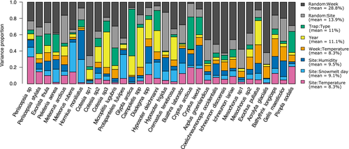

**FIGURE 2**

Open in figure viewer[PowerPoint](https://besjournals.onlinelibrary.wiley.com/action/downloadFigures?id=jane13415-fig-0002&doi=10.1111%2F1365-2656.13415)

Looking at the directional responses of the species to the environmental conditions, we observe the following patterns (Figure 3): 12 out of 32 species responded to site temperature with posterior *p* ≥ 0.95, among which positive and negative responses occurred equally. Thirteen out of 32 species responded to the timing of snow melt with posterior *p* ≥ 0.95, among which most preferred early‐melting sites and just a few later snowmelt. Roughly half of the parasitoid species responded to humidity with posterior *p* ≥ 0.95, out of which most preferred drier sites. Thirteen out of 32 species responded to the second sampling year positively with posterior *p* ≥ 0.95 whereas none of the species showed negative responses, meaning that either parasitoid abundances or their activity levels were higher in 2016. Likewise, half of the parasitoid species were more likely to be caught in sticky traps with posterior *p* ≥ 0.95, whereas none showed negative responses, meaning that sticky traps were overall more efficient in catching parasitoids than emergence traps. Finally, most parasitoids (20 out of 32) responded positively to the week‐specific temperature with posterior *p* ≥ 0.95, meaning that more species were caught in warmer than cooler weeks. We note that this variable also captures some phenological effects, as weeks in the middle of the summer tend to be warm. Also part of the interannual variation in species occurrences may be captured by weekly temperatures as the interannual variation in temperature was retained in this variable.

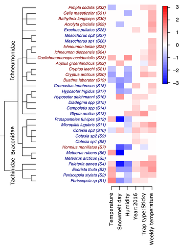

**FIGURE 3**

Open in figure viewer[PowerPoint](https://besjournals.onlinelibrary.wiley.com/action/downloadFigures?id=jane13415-fig-0003&doi=10.1111%2F1365-2656.13415)

Mean posterior regression parameter values (scaled by the range of the covariate values in the data) measuring the species‐specific responses of parasitoids to each of the covariates included in the HMSC model. Blue colours indicate negative responses and red colours represent positive responses with ≥0.95 posterior probability. Species are shown in rows and covariates in columns, and a tree showing the taxonomical relationships among the species has been plotted next to the species names. The species names have been coloured to indicate their parasitism strategy, koinobions are being represented in blue and idiobionts in red

#### 3.1.1 The effect of species traits on environmental responses

Parasitism strategy and species phenology explained 30% of the variation in species responses to the environmental variables included in the model. Species responded distinctively to abiotic variation depending on their parasitism strategy (Figure 4). The proportion of koinobiont species increased whereas the portion of idiobiont species decreased with higher site‐specific temperature (or higher elevation; Figure 4a). Likewise, the proportion of koinobiont species decreased whereas the portion of idiobiont species increased with later snow melt days or higher humidity at the site (Figure 4b,c). Furthermore, species with different phenologies responded substantially differently to the abiotic conditions (Figure 4). The proportion of species of medium and late phenology grew as site‐level temperature increased, whereas the proportion of species of early phenology decreased (Figure 4d,g). The date of snow melt also had a strong effect on community‐level trait composition. The proportion of species of medium and late phenologies increased, whereas the portion of species of early phenology decreased with an advance in the date of snow melt (Figure 4e,h). Site‐level humidity had no detectable effect on the phenology of the parasitoid species.

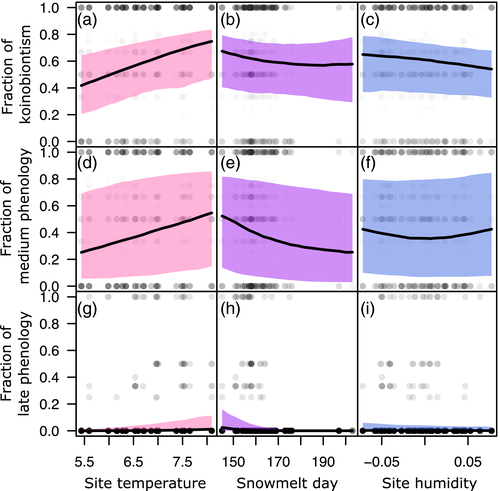

**FIGURE 4**

Open in figure viewer[PowerPoint](https://besjournals.onlinelibrary.wiley.com/action/downloadFigures?id=jane13415-fig-0004&doi=10.1111%2F1365-2656.13415)

Model predictions showing the expected fractions of parasitoid species with different life cycle strategies (a–c) and phenologies (d–f for medium and g‐I for late species) along the abiotic gradients. The first column of panels shows the predictions for site‐specific temperature, the second column for the timing of snowmelt and the last column for humidity. In all predictions year is set to 2015 and other non‐focal variables are kept at their mean values

### 3.2 Parasitism by koinobiont species

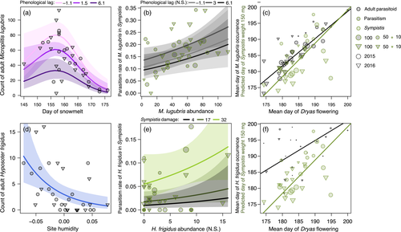

**FIGURE 5**

Open in figure viewer[PowerPoint](https://besjournals.onlinelibrary.wiley.com/action/downloadFigures?id=jane13415-fig-0005&doi=10.1111%2F1365-2656.13415)

Abundance patterns, parasitism rates and phenologies of the most abundant koinobiont parasitoids, *Microplitis lugubris* (a–c) and *Hyposoter frigidus* (d–f) in relation to abiotic conditions. Panel (a) shows the site‐specific abundance of adult *M. lugubris* on the snowmelt timing gradient. The additional effect of phenological matching with *Dryas* flowering is shown by progressively darker colours indicating an increasing time lag between the mean *Dryas* flowering and the parasitoid mean flight period (phenological lag). The respective fitted lines are shown with 95% confidence intervals of different colours, representing the 5%, 50% and 95% quantile of the variable. Panel (b) shows parasitism rates in *Sympistis* larvae in relation to the number of adult *M. lugubris* at the site level and the additional, nonsignificant, effect of phenological lag. Panel (c) shows the phenological relationships of the three trophic levels. The grey markers and fitted line show mean flight times of *M. lugubris* at the sampling sites as a function of mean *Dryas* flowering day. The green markers and the fitted line show the predicted day when larvae of *Sympistis zetterstedtii* would weigh on average of 150 mg at the respective sampling site. The sizes of plots indicate the number on observations used for the calculation of these dates. Panel (d) shows the abundance of adult *H. frigidus* along a gradient of increasing site‐level humidity or moisture. Panel (e) shows the nonsignificant effect of adult *H. frigidus* abundance on the species’ parasitism rate in *S. zetterstedtii* larvae. The additional curves show the effect of florivory levels observed at the site (as a measure of host abundance), with progressively greener colours indicating fits for higher plant damage. Panel (f) shows the phenology of *H. frigidus* as function of mean *Dryas* flowering contrasted against the development of its *Sympistis* host larvae as in panel (c). Lines show fitted means surrounded by 95% confidence intervals in colour. Data‐points are marked with circles for 2015 and triangles for 2016

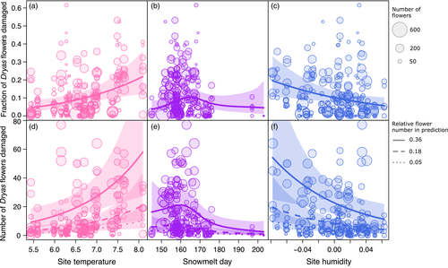

**FIGURE 6**

Open in figure viewer[PowerPoint](https://besjournals.onlinelibrary.wiley.com/action/downloadFigures?id=jane13415-fig-0006&doi=10.1111%2F1365-2656.13415)

For *H. frigidus*, the patterns were quite different. This species occurred in the greatest numbers at the driest sites (Figure 5d; Table S4). Surprisingly, the abundance of *Hyposoter* encountered in host larvae was only weakly related to the abundance of adult wasps encountered in the traps of the same site. Instead, parasitism rates tracked local herbivory levels (Figure 5e; Table S5). The phenological match between *H. frigidus* occurrence and *Dryas* flowering did not detectably affect either the abundance of adult *H. frigidus* or the species’ parasitism rates on *Sympistis* larvae. Compared to *M lugubris* (above), *H. frigidus* also flew later (note higher intercept in Figure 5f than 5c) and showed a shallower phenological response (lower slope in Figure 5f than 5c), with parasitoids lagging further behind *Dryas* flowering at earlier sites (Figure 5f).

## 4 DISCUSSION

In a warming world, changes in climate may result in interconnected changes in species’ response, community structure and interaction outcomes such as predation and herbivory. Yet, the interconnections between these levels are still inadequately understood. Targeting the High Arctic, we find that local parasitoid communities are strongly affected by microclimatic variation, and that community‐level change can be attributed to variation in particular traits. Importantly, the same microclimatic variation also reflects into predation (parasitism) and herbivory rates. Below, we will discuss each finding in turn.

### 4.1 How do parasitoid communities vary with microclimatic conditions?

At the level of parasitoid communities, we found clear spatial patterns within a single habitat. The composition of parasitoid communities was mainly associated with the snow melting dates and soil humidity conditions. Much of this variation was related to the dichotomy of parasitoids adhering to either idiobiont or koinobiont parasitism strategy. These life history strategies have been previously found to affect species responses to climatic variation along elevation (Péré et al., 2013) and geographical gradients (Kankaanpää, Vesterinen, et al., 2020; Timms et al., 2016). In particular, parasitoids with a koinobiont strategy preferred sites with higher summer temperatures (at higher elevations), and—to lesser degree—sites with early snowmelt and low humidity (Figure 4). The association with higher summer temperatures is at odds with other previous studies (Kankaanpää, Vesterinen, et al., 2020; Péré et al., 2013; Timms et al., 2016) This apparent contradiction may be explained by the particular topography of our study site, where the warmest summer temperatures were recorded at the highest elevations due to a local temperature inversion phenomenon (see Section 2.1). During the winter these sites may conversely have the coldest soil temperatures, which might be why the less cold‐hardy idiobiont parasitoids are less likely to occur.

Part of this koinobiont affinity to warm high‐elevation sites is attributable to the fact that many of the koinobionts in our data are tachinids. Tachinids fall somewhere in between the koino‐ and idiobiont strategies, since they are not fully surrounded by host tissue (Dindo, 2011). Instead, they maintain a breathing connection to the outside. This reduces the need for manipulating host physiology, and makes it harder for the host to suffocate the developing parasitoid larva by encapsulation, which is a common defence strategy against other parasitoids (Stireman, 2016). Such a breathing strategy is likely to make tachinids less sensitive to temperature as mediated by changes in host immunity. At the same time, high‐arctic tachninids manipulate the host to seek sheltered overwintering sites (Reitz & Nettles, 1994), which allows them to colonize otherwise exposed areas. Over time, tachinid abundances increase with temperatures in the Zackenberg monitoring time series (Figure S6), thereby supporting a joint imprint of climatic variation in space (current study) and over time.

Within the idiobionts, we identified two phylogenetically linked response types. Species in the subfamilies Cryptinae and Pimplinae have relatively long ovipositors, and occurred in in dry lowland areas (i.e. sites with low humidity and high site‐level temperature). Such a habitat preference may be associated with the larger grained sandy soil through which host prepupae can be reached. As an alternative, these sites may simply be rich in suitable hosts, while still maintaining more sheltered microhabitats during the winter than do the high‐elevation sites of our study area. The second group is the subfamily Ichneumoninae, some species of which were associated with wetter, late‐melting sites. This group includes species which overwinter as adults (Várkonyi & Roslin, 2013) and which might thus require more insulation from snow cover.

One mechanism through which local climate can exert differential spatial filtering among species is through phenology (Hodgson et al., 2011). Species which are active early in the growing season are subjected to different conditions than those active in the late season. Our model predicted a larger representation of medium and late phenology species in warmer high‐elevation sites and in sites with early snowmelt. The late‐flying species risk emerging too late at cooler sites, and may thus be restricted to areas with earlier phenology in Zackenberg. Overall, they may thus benefit from the delayed onset of winter with increasing temperatures.

### 4.2 How do parasitism rates vary with microclimate?

Microclimatic impacts were also evident in terms of parasitism rates. In the parasitoids causing the most larval mortality, *M. lugubris,* parasitism rates grew with increasing abundances of adult parasitoids—as is clearly to be expected for a specialist parasitoid. For *H. frigidus,* a more generalistic parasitoid, parasitism rates in *Sympistis* larvae were less related to adult parasitoid abundance, but were high at sites with heavy current herbivory.

One of the key mechanisms through which climate change is expected to affect herbivore–parasitoid interactions, is through diverging phenologies between the parasitoid and lower trophic levels (Thierry et al., 2019; Tougeron et al., 2019; Van Nouhuys & Lei, 2004; Wetherington et al., 2017). Consistent with this notion, we found a tight phenological association between the species, *M. lugubris,* and the flower‐feeding moth larvae of *S. zetterstedtii*. The parasitism rates also showed a suggestive, but nonsignificant pattern of peak phenology matching with *Dryas* flowering. These findings are supported by studies on other *Microplitis* species, which consistently show poorer survival in host larvae which have ‘escaped in time’, i.e. attained larger size through faster development in higher temperatures (Hegazi & Khafagi, 2005). Availability of flower resources can drastically increase parasitoid fecundity (Berndt et al., 2002; Winkler et al., 2006; Witting‐Bissinger et al., 2008). Thus, matching the phenology of the primary producers may be of importance to *M. lugubris,* which actively visits *Dryas* flowers (Tiusanen et al., 2016). Importantly, both the years of our study (2015–2016) were characterized by snowmelt being late from a decadal perspective (mean snow melt DoY of permanent arthropod sampling sites 169 in 2015 and 160 in 2016 compared to a mean of 158 and *SD* of 7.8 for 1996–2016). This leaves open the possibility that a wider phenological mismatch could occur during years with early snowmelt, contributing to the elevated levels of herbivory observed following snow‐free winters and warm summers (Kankaanpää, Vesterinen, et al., 2020).

The parasitism rates of *H. frigidus* showed a somewhat different pattern. Adult *Hyposoter* occurrence was more limited to dry and exposed habitats than was parasitism by *Microplitis*. Parasitism rates of *Sympistis* larvae were also much larger in areas on which considerable herbivore damage was also recorded, suggesting high host abundances. For *Hyposoter*, temporal matching with the host or with *Dryas* had no effect on either adult parasitoid abundance or parasitism rates. That phenological matching with *Sympistis* larvae and *Dryas* flowering is more lax in *Hyposoter* than in *Microplitis* is perhaps not surprising, given that *Hyposoter* has a much wider host range and uses hosts from at least four families of Lepidoptera (Várkonyi & Roslin, 2013).

How climatic effects on parasitoids and parasitism translate to suppression of hosts cannot be established based on spatial patterns alone. To our knowledge, no comprehensive generalized comparison of potential for host suppression between idiobionts and koinobionts has been conducted. Neither do we yet have a comprehensive picture of how climate change affects parasitism rates in herbivorous insects (Thierry et al., 2019). On natural elevation gradients, parasitism rates—especially those of idiobiont parasitoids—typically decrease with elevation and decreasing temperatures (Maunsell et al., 2015; Péré et al., 2013; Vindstad et al., 2011). The importance of summer temperatures on parasitism rates is highlighted when the relationship between elevation and temperature is not as simple, like in our study or e.g. that by Virtanen and Neuvonen (1999), who found a positive association between the total parasitism rate in larvae of the moth *Epirrita autumnata* (Borkhausen, 1794) and the temperature during larval period. Taken alone, this would entail rising parasitism rates with rising overall temperatures, but experiments including e.g. the accompanying rise in CO<sub>2</sub> levels suggest otherwise (Dyer et al., 2013). All in all, what our study shows is that the same climatic affects which shape parasitoid communities also apply to parasitism rates in the High Arctic. This is of key importance in a changing climate, resulting in a predictable change over time.

### 4.3 How does herbivory vary with climate?

Herbivory, both by insects and vertebrates, plays a crucial role in modulating the effects of climate change, by buffering the plant community against change (Kaarlejärvi et al., 2013, 2017, 2015), affecting the direction of plant community change (La Pierre et al., 2015; Pellissier et al., 2018) and ultimately nutrient cycling (Risch et al., 2015) and carbon balance (Lund et al., 2017). In our study, we found more flower damage with higher summer‐time temperatures and dryer conditions. These findings are consistent with large‐scale patterns suggesting increasing insect herbivory in warming Arctic tundra habitats. These predictions originate from experimental setups (Birkemoe et al., 2016; de Sassi et al., 2012; Liu et al., 2011; Roy et al., 2004) and increasingly from natural systems (Barrio et al., 2017; Rheubottom et al., 2019).

In terms of humidity, we found drier habitats to exhibit higher levels of *Dryas* folivory. That water balance is an important modulator of effects of temperature was also shown by Romo et al. (2013) in an aphid system. For *Dryas,* water availability has been shown to reduce plant quality from a herbivore perspective, by decreasing the nitrogen to carbon ratio (Welker et al., 1997). In the Arctic, however, much or the water is received as snow, and snow cover increases winter soil temperatures and guards against disruptive freeze‐thaw cycles, thereby facilitating nutrient cycling by soil micro‐organisms (Li et al., 2016; Sorensen et al., 2018). This can lead to higher nitrogen concentrations and herbivore performance, as seen in a dwarf birch system (Torp et al., 2010). As a net outcome, increased water availability from sources other than the local snow cover can thus reduce host plant quality, at least in *Dryas*. How this affects the overall severity of herbivory remains to be seen, but our findings suggest an increase in *Dryas* florivory in areas where rising summer temperatures are accompanied by drying of top soils.

Overall, herbivory levels are determined by many factors, such as host–plant quality, herbivore efficiency (Greyson‐Gaito et al., 2016), mortality to predation (Clavijo McCormick, 2016; Li et al., 2019) and other causes such as pathogens. The dynamics controlling herbivory are complex, involving direct effects, trophic cascades and, as increasingly more evident, effects mediated by endosymbiont (Duplouy & Hornett, 2018; Oliver et al., 2012). The effects of warming on herbivory are determined by both indirect effects through species interactions, and direct physiological effects on both plants and herbivores. (Thierry et al., 2019). As nearly all studies of herbivory, including ours, have focused on a single compartment within the wider interaction network, more holistic approaches to studying herbivory should be a future priority.

## 5 CONCLUSIONS

Our results show that parasitoid community assembly is affected by microclimatic variation, and that the same microclimatic variation is also reflected in parasitism rates and levels of herbivory. These patterns suggest that current, ongoing changes in macroclimate may translate into widespread changes in the sensitive Arctic. Most importantly, while different species respond differently to climate, part of this variation can be attributed to variation in particular species traits. Our findings suggest that it may be possible to make general trait‐based predictions regarding future changes in arctic communities and species interactions.

## ACKNOWLEDGEMENTS

We are grateful for the infrastructure and data maintained by Greenland Ecosystem Monitoring Programme provided by the Department of Bioscience, Aarhus University, Denmark in collaboration with Greenland Institute of Natural Resources, Nuuk, Greenland, and the Department of Biology, University of Copenhagen, Denmark and for the data from the Greenland Ecosystem Monitoring Programme provided by Asiaq – Greenland Survey, Nuuk, Greenland. The Biomedicum Functional Genomics Unit (FuGU) and the Institute for Molecular Medicine Finland (FIMM) are thanked for sequencing services. We acknowledge CSC–IT Center for Science Ltd., Espoo, Finland, for the allocation of computational resources. We gratefully acknowledge funding from the Academy of Finland (grants 276909, 285803 to T.R.), Nessling foundation (grants 201700420, 201600034, 201500090 to T.K.), The Ella and Georg Ehrnrooth Foundation, Jane and Aatos Erkko Foundation, *Societas pro Fauna et Flora Fennica* and Carl Tryggers Stiftelse för Vetenskaplig Forskning (grant CTS 17:383 to T.R.). We thank Tea Huotari, Elisabet Ottosson, Mikko Tiusanen and Bernhard Eitzinger for their assistance in the field. Finally, we are especially grateful to Marjo Kilpinen and Eija Takala for their invaluable assistance in the laboratory.

## AUTHORS' CONTRIBUTIONS

The study was designed by T.K. and T.R.; Field collections were implemented and carried out by T.K.; Laboratory workflow was designed by E.V. and T.K.; Laboratory work was carried out by T.K. with assistance of the technical staff of the department of agricultural sciences at the University of Helsinki; Raw sequencing data were processed by E.V. with further processing done by T.K.; Joint species distribution models were fit by N.A. and T.K. Other statistical analyses were conducted by T.K. All authors partook in writing and revising the manuscript.

## REFERENCES

[figure not shown]

[Early View](https://besjournals.onlinelibrary.wiley.com/toc/13652656/0/0)

Online Version of Record before inclusion in an issue

### Details

- © 2020 The Authors. *Journal of Animal Ecology* published by John Wiley & Sons Ltd on behalf of British Ecological Society

  This is an open access article under the terms of the [Creative Commons Attribution‐NonCommercial](http://creativecommons.org/licenses/by-nc/4.0/) License, which permits use, distribution and reproduction in any medium, provided the original work is properly cited and is not used for commercial purposes.

[figure not shown]

### Keywords

  - Arctic
  - [climate change](https://besjournals.onlinelibrary.wiley.com/action/doSearch?field1=Keyword&text1=climate%20change)
  - [community ecology](https://besjournals.onlinelibrary.wiley.com/action/doSearch?field1=Keyword&text1=community%20ecology)
  - herbivory
  - parasitoid
  - [species traits](https://besjournals.onlinelibrary.wiley.com/action/doSearch?field1=Keyword&text1=species%20traits)

### Funding Information

  - Carl Tryggers Stiftelse för Vetenskaplig Forskning. Grant Number: CTS 17:383
  - Maj ja Tor Nesslingin Säätiö. Grant Numbers: 201500090, 201600034, 201700420
  - Jane ja Aatos Erkon Säätiö
  - Suomen Akatemia. Grant Numbers: 276909, 285803
  - Ella ja Georg Ehrnroothin Säätiö
  - Societas pro Fauna et Flora Fennica

### Publication History

  - Version of Record online: 13 January 2021
  - Accepted manuscript online: 24 December 2020
  - Manuscript accepted: 14 December 2020
  - Manuscript received: 19 February 2020

[Download PDF](https://besjournals.onlinelibrary.wiley.com/doi/pdf/10.1111/1365-2656.13415)